# Treasure Hunt Game Notebook

## Read and Review Your Starter Code

The theme of this project is a popular treasure hunt game in which the player needs to find the treasure before the pirate does. While you will not be developing the entire game, you will write the part of the game that represents the intelligent agent, which is a pirate in this case. The pirate will try to find the optimal path to the treasure using deep Q-learning.

**To Begin:** Use this **TreasureHuntGame_starterCode.ipynb** file to complete your assignment.  
You have been provided with two Python classes and this notebook to help you with this assignment. The first class, **TreasureMaze.py**, represents the environment, which includes a maze object defined as a matrix. The second class, **GameExperience.py**, stores the episodes – that is, all the states that come in between the initial state and the terminal state. This is later used by the agent for learning by experience, called "exploration". This notebook shows how to play a game. Your task is to complete the deep Q-learning implementation in the qtrain() function for which a skeleton implementation has been provided.

**NOTE:** The code block you will need to complete will have **#TODO** as a header.  
First, read and review the next few code and instruction blocks to understand the code that you have been given.

**Installations** The following command will install the necessary Python libraries to necessary to run this application. If you see a "[notice] A new release of pip is available: 23.1.2 -> 25.2" at the end of the installation, you may disregard that statement.

```python
!pip install -r requirements.txt
```

## Tensorflow CPU Acceleration Warning

**GPU/CUDA/Memory Warnings/Errors:** You may receive some errors referencing that GPUs will not be used, CUDA could not be found, or free system memory allocation errors. These and a few others, are standard errors that can be ignored here as they are environment based.  
**Example messages:**

- oneDNN custom operations are on. You may see slightly different numerical results due to floating-point round-off errors from different computation orders
- WARNING: All log messages before absl::InitializeLog() is called are written to STDERR

```python
from __future__ import print_function
import os, sys, time, datetime, json, random
import numpy as np
import tensorflow as tf
from tensorflow.keras.models import clone_model
from keras.models import Sequential
from keras.layers import Dense, Activation, PReLU
from keras.optimizers import SGD , Adam, RMSprop
import matplotlib.pyplot as plt
from TreasureMaze import TreasureMaze
from GameExperience import GameExperience
%matplotlib inline
```

```
WARNING:tensorflow:From C:\Users\apg84\Downloads\pirate-intelligent-agent\.venv\Lib\site-packages\keras\src\losses.py:2976: The name tf.losses.sparse_softmax_cross_entropy is deprecated. Please use tf.compat.v1.losses.sparse_softmax_cross_entropy instead.
```

## Maze Object Generation

**NOTE:** The following code block contains an 8x8 matrix that will be used as a maze object:

```python
maze = np.array([
    [ 1.,  0.,  1.,  1.,  1.,  1.,  1.,  1.],
    [ 1.,  0.,  1.,  1.,  1.,  0.,  1.,  1.],
    [ 1.,  1.,  1.,  1.,  0.,  1.,  0.,  1.],
    [ 1.,  1.,  1.,  0.,  1.,  1.,  1.,  1.],
    [ 1.,  1.,  0.,  1.,  1.,  1.,  1.,  1.],
    [ 1.,  1.,  1.,  0.,  1.,  0.,  0.,  0.],
    [ 1.,  1.,  1.,  0.,  1.,  1.,  1.,  1.],
    [ 1.,  1.,  1.,  1.,  0.,  1.,  1.,  1.]
])
```

## Helper Functions and Global Variables

This **show()** helper function allows a visual representation of the maze object:

```python
def show(qmaze):
    plt.grid('on')
    nrows, ncols = qmaze.maze.shape
    ax = plt.gca()
    ax.set_xticks(np.arange(0.5, nrows, 1))
    ax.set_yticks(np.arange(0.5, ncols, 1))
    ax.set_xticklabels([])
    ax.set_yticklabels([])
    canvas = np.copy(qmaze.maze)
    for row,col in qmaze.visited:
        canvas[row,col] = 0.6
    pirate_row, pirate_col, _ = qmaze.state
    canvas[pirate_row, pirate_col] = 0.3   # pirate cell
    canvas[nrows-1, ncols-1] = 0.9 # treasure cell
    img = plt.imshow(canvas, interpolation='none', cmap='gray')
    return img
```

The **pirate agent** can move in four directions: left, right, up, and down.

**Note:** While the agent primarily learns by experience through exploitation, often, the agent can choose to explore the environment to find previously undiscovered paths. This is called "exploration" and is defined by epsilon. This value is the **EXPLORATION** values from the Cartpole assignment. The hyperparameters are provided here and used in the **qtrain()** method. You are encouraged to try various values for the exploration factor and see how the algorithm performs.

```python
LEFT = 0
UP = 1
RIGHT = 2
DOWN = 3


# Exploration factor
epsilon = 1.0
epsilon_min = 0.05
epsilon_decay = 0.995
patience = 10

# Actions dictionary
actions_dict = {
    LEFT: 'left',
    UP: 'up',
    RIGHT: 'right',
    DOWN: 'down',
}

num_actions = len(actions_dict)
```

The sample code block and output below show creating a maze object and performing one action (DOWN), which returns the reward. The resulting updated environment is visualized.

```
reward= -0.04
```

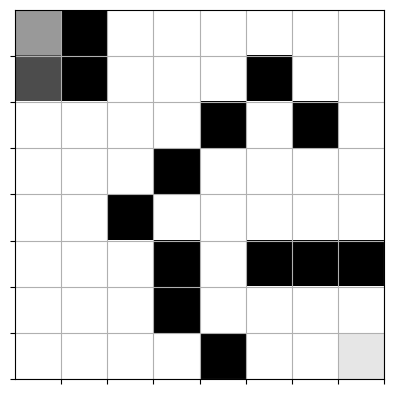

```python
qmaze = TreasureMaze(maze)
canvas, reward, game_over = qmaze.act(DOWN)
print("reward=", reward)
show(qmaze)
```

**NOTE:** This **play_game()** function simulates a full game based on the provided trained model. The other parameters include the TreasureMaze object, the starting position of the pirate and max amount of steps to make sure the code does not get stuck in a loop.

```python
def play_game(model, qmaze, pirate_cell, max_steps=None):
    qmaze.reset(pirate_cell)
    envstate = qmaze.observe()
    steps = 0
    if max_steps is None:
        max_steps = qmaze.maze.size * 4  # safety cutoff

    while steps < max_steps:
        state = np.asarray(envstate, dtype=np.float32)
        if state.ndim == 1:
            state = np.expand_dims(state, axis=0)

        q_values = model(state, training=False).numpy()
        action = np.argmax(q_values[0])

        envstate, reward, game_status = qmaze.act(action)
        steps += 1

        if game_status == 'win':
            return True
        elif game_status == 'lose':
            return False

    return False  # timed out with no result
```

**Note:** This **completion_check()** function helps you to determine whether the pirate can win any game at all. If your maze is not well designed, the pirate may not win any game at all. In this case, your training would not yield any result. The provided maze in this notebook ensures that there is a path to win and you can run this method to check.

```python
def completion_check(model, maze_or_qmaze, max_steps=None):
    # Accept either raw numpy maze or TreasureMaze instance
    if isinstance(maze_or_qmaze, TreasureMaze):
        qmaze = maze_or_qmaze
    else:
        qmaze = TreasureMaze(maze_or_qmaze)

    for cell in qmaze.free_cells:
        if not qmaze.valid_actions(cell):
            continue
        if not play_game(model, qmaze, cell, max_steps=max_steps):
            return False
    return True
```

**Note:** The **build_model()** function in the block below will build the neural network model. Review the code and note the number of layers, as well as the activation, optimizer, and loss functions that are used to train the model.

```python
def build_model(maze):
    model = Sequential()
    model.add(Dense(maze.size, input_shape=(maze.size,)))
    model.add(PReLU())
    model.add(Dense(maze.size))
    model.add(PReLU())
    model.add(Dense(num_actions))
    model.compile(optimizer='adam', loss='mse')
    return model
```

**Note:** This **train_step()** helper function in the block below is used to help predict Q-values (quality values) in the current modelto see how good each action is in a given state and improve the Q-network by reducing the gap between what is predicted and what should have been predicted.

If you're interested in reading up on the *@tf.function*, which is a decorator for Tensorflow to run this code into a TensorFlow computation graph, please refer to this link: https://www.tensorflow.org/guide/intro_to_graphs

## Tensorflow GPU Warning

You will see a **warning in red** "INTERNAL: CUDA Runtime error: Failed call to cudaGetRuntimeVersion: Error loading CUDA libraries. GPU will not be used.". This is simply coming from **Tensorflow skipping using GPU for this assignment.**

```python
loss_fn = tf.keras.losses.MeanSquaredError()
optimizer = tf.keras.optimizers.Adam()

@tf.function
def train_step(x, y):
    with tf.GradientTape() as tape:
        q_values = model(x, training=True)
        loss = loss_fn(y, q_values)
    grads = tape.gradient(loss, model.trainable_variables)
    optimizer.apply_gradients(zip(grads, model.trainable_variables))
    return loss
```

# #TODO: Complete the Q-Training Algorithm Code Block

This is your deep Q-learning implementation. The goal of your deep Q-learning implementation is to find the best possible navigation sequence that results in reaching the treasure cell while maximizing the reward. In your implementation, you need to determine the optimal number of epochs to achieve a 100% win rate.

**Pseudocode:**  
For each epoch: Reset the environment at a random starting cell agent_cell = randomly select a free cell  
**Hint:** Review the reset method in the TreasureMaze.py class.

```
    Set the initial environment state
    env_state should reference the environment's current state
    Hint: Review the observe method in the TreasureMaze.py class.

    While game status is not game over:
       previous_envstate = env_state
        Decide on an action:
            - If possible, take a random valid exploration action and
              randomly choose action (left, right, up, down)
              and assign it to an action variable
            - Else, pick the best exploitation action from the model and assign it to an action variable
              Hint: Review the predict method in the GameExperience.py class.

       Retrieve the values below from the act() method.
       env_state, reward, game_status = qmaze.act(action)
       Hint: Review the act method in the TreasureMaze.py class.

        Track the wins and losses from the game_status using win_history

       Store the episode below in the Experience replay object
       episode = [previous_envstate, action, reward, envstate, game_status]
       Hint: Review the remember method in the GameExperience.py class.

       Train neural network model and evaluate loss
       Hint: Call GameExperience.get_data to retrieve training data (input and target)
       and pass to the train_step method and assign it to batch_loss and append to the loss variable

  If the win rate is above the threshold and your model passes the completion check, that would be your epoch.
```

Note: A 100% win rate **DOES NOT EXPLICITLY MEAN** that you have solved the maze. It simply indicates that during the last evaluation, the pirate *happened* to get to the treasure. Be sure to utilise the **completion_check()** function to validate your pirate found the treasure at every starting point and consistently!

**You will need to complete the section starting with #START_HERE. Please use the pseudocode above as guidance.**

```python
def qtrain(model, maze, **opt):
    """
    Trains a Deep Q-Learning (DQN) agent to solve the TreasureMaze.

    This function is the only student-modified section of the project.
    The environment (TreasureMaze) and replay system (GameExperience)
    remain unchanged per assignment instructions.

    The training process uses:
    - Experience replay
    - Target network stabilization
    - Epsilon-greedy exploration
    - Gradual transition to evaluation-style policy (unmasked argmax)
    """

    global epsilon

    # -----------------------------
    # Training configuration
    # -----------------------------
    n_epoch = opt.get('n_epoch', 1000)
    max_memory = opt.get('max_memory', 8 * maze.size)
    data_size = opt.get('data_size', 32)
    target_update_freq = opt.get('target_update_freq', 50)
    gamma = opt.get('gamma', 0.95)

    # Episode limits to prevent infinite wandering
    max_steps = opt.get('max_steps', maze.size * 4)

    # Allow replay memory to fill before heavy training begins
    warmup_episodes = opt.get('warmup_episodes', 25)

    # Extra replay batches after each episode improves stability
    train_batches = opt.get('train_batches', 1)

    # Completion / stopping conditions
    win_rate_goal = opt.get('win_rate_goal', 0.98)
    check_freq = opt.get('check_freq', 25)
    min_epochs_before_check = opt.get('min_epochs_before_check', 100)

    # After this point, training matches play_game() policy (no masking)
    align_with_play_game_epoch = opt.get('align_with_play_game_epoch', 150)

    # Number of actions (usually 4: up, right, down, left)
    n_actions = opt.get('n_actions', 4)

    start_time = datetime.datetime.now()
    qmaze = TreasureMaze(maze)

    # -----------------------------
    # Target network (stabilizes learning)
    # -----------------------------
    target_model = clone_model(model)
    target_model.set_weights(model.get_weights())

    # Experience replay memory handler
    experience = GameExperience(model, target_model,
                                max_memory=max_memory,
                                discount=gamma)

    win_history = []
    hsize = max(10, qmaze.maze.size // 2)
    win_rate = 0.0

    # ==========================================================
    # Main Training Loop
    # ==========================================================
    for epoch in range(n_epoch):

        # Start from a random valid position each episode
        agent_cell = random.choice(qmaze.free_cells)
        qmaze.reset(agent_cell)
        envstate = qmaze.observe()

        game_over = False
        losses = []
        steps = 0

        # ------------------------------------------------------
        # Episode Loop
        # ------------------------------------------------------
        while not game_over and steps < max_steps:
            previous_envstate = envstate

            valid_actions = qmaze.valid_actions()
            if not valid_actions:
                # No possible moves -> treat as terminal
                game_over = True
                break

            # After enough training, use same policy as evaluation
            use_unmasked_policy = (epoch >= align_with_play_game_epoch)

            # --------------------------------------------------
            # Epsilon-Greedy Action Selection
            # --------------------------------------------------
            if np.random.rand() < epsilon:
                # Exploration
                if use_unmasked_policy:
                    # Explore full action space (includes invalid)
                    action = random.randrange(n_actions)
                else:
                    # Early phase: restrict exploration to valid moves
                    action = random.choice(valid_actions)
            else:
                # Exploitation (choose best predicted Q value)
                q_values = experience.predict(previous_envstate)

                if use_unmasked_policy:
                    # Match play_game(): plain argmax over all actions
                    action = int(np.argmax(q_values))
                else:
                    # Mask invalid actions during early learning
                    masked_q = np.full_like(q_values, -np.inf, dtype=np.float32)
                    masked_q[valid_actions] = q_values[valid_actions]
                    action = int(np.argmax(masked_q))

            # --------------------------------------------------
            # Execute Action in Environment
            # --------------------------------------------------
            envstate, reward, game_status = qmaze.act(action)
            game_over = (game_status != 'not_over')

            # Store transition in replay memory
            experience.remember(
                [previous_envstate, action, reward, envstate, game_over]
            )

            # --------------------------------------------------
            # Train from Replay Memory
            # --------------------------------------------------
            if epoch >= warmup_episodes and len(experience.memory) >= data_size:
                inputs, targets = experience.get_data(batch_size=data_size)
                batch_loss = float(model.train_on_batch(inputs, targets))
                losses.append(batch_loss)

            steps += 1

        # ------------------------------------------------------
        # Track Win / Loss
        # ------------------------------------------------------
        if not game_over and steps >= max_steps:
            game_status = 'lose'
            win_history.append(0)
        else:
            win_history.append(1 if game_status == 'win' else 0)

        # ------------------------------------------------------
        # Update Target Network (stability)
        # ------------------------------------------------------
        if (epoch + 1) % target_update_freq == 0:
            target_model.set_weights(model.get_weights())

        # Optional additional training batches
        if epoch >= warmup_episodes and len(experience.memory) >= data_size:
            for _ in range(max(0, train_batches - 1)):
                inputs, targets = experience.get_data(batch_size=data_size)
                batch_loss = float(model.train_on_batch(inputs, targets))
                losses.append(batch_loss)

        # ------------------------------------------------------
        # Compute Rolling Win Rate
        # ------------------------------------------------------
        if len(win_history) >= hsize:
            win_rate = sum(win_history[-hsize:]) / hsize

        # Gradually reduce exploration
        epsilon = max(epsilon * epsilon_decay, epsilon_min)

        # ------------------------------------------------------
        # Training Progress Output
        # ------------------------------------------------------
        loss = float(np.mean(losses)) if losses else 0.0
        dt = datetime.datetime.now() - start_time
        t = "%.1f seconds" % dt.total_seconds()

        print(
            "Epoch: {:04d}/{:04d} | Loss: {:.4f} | Steps: {:03d} | Wins: {:d} | WinRate({:d}): {:.3f} | Eps: {:.3f} | time: {}".format(
                epoch + 1, n_epoch, loss, steps,
                sum(win_history), hsize, win_rate, epsilon, t
            )
        )

        # ------------------------------------------------------
        # Completion Check
        # ------------------------------------------------------
        if (epoch + 1) >= min_epochs_before_check and (epoch + 1) % check_freq == 0:
            if win_rate >= win_rate_goal:
                # Allow more steps during evaluation than training
                check_steps = max_steps * 2
                if completion_check(model, qmaze, max_steps=check_steps):
                    print("Solved maze with completion_check at epoch:", epoch + 1)
                    break

    dt = datetime.datetime.now() - start_time
    print("Training complete in:", dt.total_seconds(), "seconds")
```

## Test Your Model

Now we will start testing the deep Q-learning implementation. To begin, select **Cell**, then **Run All** from the menu bar. This will run your notebook. As it runs, you should see output begin to appear beneath the next few cells. The code below creates an **instance** of TreasureMaze. This does not show your actual training done.

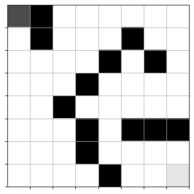

```python
qmaze = TreasureMaze(maze)
show(qmaze)
```

In the next code block, you will build your model using the **build_model** function and train it using deep Q-learning. Note: This step takes several minutes to fully run.

**WARNING** If you did not attempt the assignment, the code **will** error out at this section.

```python
model = build_model(maze)
qtrain(model, maze, n_epoch=1000, max_memory=8*maze.size, data_size=32, target_update_freq=50)
```

```
WARNING:tensorflow:From C:\Users\apg84\Downloads\pirate-intelligent-agent\.venv\Lib\site-packages\keras\src\backend.py:873: The name tf.get_default_graph is deprecated. Please use tf.compat.v1.get_default_graph instead.

WARNING:tensorflow:From C:\Users\apg84\Downloads\pirate-intelligent-agent\.venv\Lib\site-packages\keras\src\optimizers\__init__.py:309: The name tf.train.Optimizer is deprecated. Please use tf.compat.v1.train.Optimizer instead.

Epoch: 0001/1000 | Loss: 0.0000 | Steps: 139 | Wins: 0 | WinRate(32): 0.000 | Eps: 0.995 | time: 0.0 seconds
Epoch: 0002/1000 | Loss: 0.0000 | Steps: 144 | Wins: 0 | WinRate(32): 0.000 | Eps: 0.990 | time: 0.0 seconds
Epoch: 0003/1000 | Loss: 0.0000 | Steps: 001 | Wins: 1 | WinRate(32): 0.000 | Eps: 0.985 | time: 0.0 seconds
Epoch: 0004/1000 | Loss: 0.0000 | Steps: 059 | Wins: 2 | WinRate(32): 0.000 | Eps: 0.980 | time: 0.1 seconds
Epoch: 0005/1000 | Loss: 0.0000 | Steps: 151 | Wins: 2 | WinRate(32): 0.000 | Eps: 0.975 | time: 0.1 seconds
Epoch: 0006/1000 | Loss: 0.0000 | Steps: 079 | Wins: 3 | WinRate(32): 0.000 | Eps: 0.970 | time: 0.1 seconds
Epoch: 0007/1000 | Loss: 0.0000 | Steps: 150 | Wins: 3 | WinRate(32): 0.000 | Eps: 0.966 | time: 0.1 seconds
Epoch: 0008/1000 | Loss: 0.0000 | Steps: 022 | Wins: 4 | WinRate(32): 0.000 | Eps: 0.961 | time: 0.1 seconds
Epoch: 0009/1000 | Loss: 0.0000 | Steps: 146 | Wins: 4 | WinRate(32): 0.000 | Eps: 0.956 | time: 0.1 seconds
Epoch: 0010/1000 | Loss: 0.0000 | Steps: 144 | Wins: 4 | WinRate(32): 0.000 | Eps: 0.951 | time: 0.1 seconds
Epoch: 0011/1000 | Loss: 0.0000 | Steps: 147 | Wins: 4 | WinRate(32): 0.000 | Eps: 0.946 | time: 0.1 seconds
Epoch: 0012/1000 | Loss: 0.0000 | Steps: 143 | Wins: 4 | WinRate(32): 0.000 | Eps: 0.942 | time: 0.1 seconds
Epoch: 0013/1000 | Loss: 0.0000 | Steps: 150 | Wins: 4 | WinRate(32): 0.000 | Eps: 0.937 | time: 0.1 seconds
Epoch: 0014/1000 | Loss: 0.0000 | Steps: 160 | Wins: 4 | WinRate(32): 0.000 | Eps: 0.932 | time: 0.2 seconds
Epoch: 0015/1000 | Loss: 0.0000 | Steps: 138 | Wins: 4 | WinRate(32): 0.000 | Eps: 0.928 | time: 0.2 seconds
Epoch: 0016/1000 | Loss: 0.0000 | Steps: 150 | Wins: 4 | WinRate(32): 0.000 | Eps: 0.923 | time: 0.2 seconds
Epoch: 0017/1000 | Loss: 0.0000 | Steps: 139 | Wins: 4 | WinRate(32): 0.000 | Eps: 0.918 | time: 0.2 seconds
Epoch: 0018/1000 | Loss: 0.0000 | Steps: 150 | Wins: 4 | WinRate(32): 0.000 | Eps: 0.914 | time: 0.2 seconds
Epoch: 0019/1000 | Loss: 0.0000 | Steps: 081 | Wins: 5 | WinRate(32): 0.000 | Eps: 0.909 | time: 0.3 seconds
Epoch: 0020/1000 | Loss: 0.0000 | Steps: 056 | Wins: 6 | WinRate(32): 0.000 | Eps: 0.905 | time: 0.3 seconds
Epoch: 0021/1000 | Loss: 0.0000 | Steps: 152 | Wins: 6 | WinRate(32): 0.000 | Eps: 0.900 | time: 0.3 seconds
Epoch: 0022/1000 | Loss: 0.0000 | Steps: 005 | Wins: 7 | WinRate(32): 0.000 | Eps: 0.896 | time: 0.3 seconds
Epoch: 0023/1000 | Loss: 0.0000 | Steps: 080 | Wins: 8 | WinRate(32): 0.000 | Eps: 0.891 | time: 0.3 seconds
Epoch: 0024/1000 | Loss: 0.0000 | Steps: 146 | Wins: 8 | WinRate(32): 0.000 | Eps: 0.887 | time: 0.3 seconds
Epoch: 0025/1000 | Loss: 0.0000 | Steps: 155 | Wins: 8 | WinRate(32): 0.000 | Eps: 0.882 | time: 0.4 seconds
WARNING:tensorflow:From C:\Users\apg84\Downloads\pirate-intelligent-agent\.venv\Lib\site-packages\keras\src\utils\tf_utils.py:492: The name tf.ragged.RaggedTensorValue is deprecated. Please use tf.compat.v1.ragged.RaggedTensorValue instead.

Epoch: 0026/1000 | Loss: 0.0058 | Steps: 031 | Wins: 9 | WinRate(32): 0.000 | Eps: 0.878 | time: 1.4 seconds
Epoch: 0027/1000 | Loss: 0.0025 | Steps: 004 | Wins: 10 | WinRate(32): 0.000 | Eps: 0.873 | time: 1.4 seconds
Epoch: 0028/1000 | Loss: 0.0040 | Steps: 160 | Wins: 10 | WinRate(32): 0.000 | Eps: 0.869 | time: 3.9 seconds
Epoch: 0029/1000 | Loss: 0.0031 | Steps: 147 | Wins: 10 | WinRate(32): 0.000 | Eps: 0.865 | time: 6.2 seconds
Epoch: 0030/1000 | Loss: 0.0027 | Steps: 147 | Wins: 10 | WinRate(32): 0.000 | Eps: 0.860 | time: 7.6 seconds
Epoch: 0031/1000 | Loss: 0.0027 | Steps: 001 | Wins: 11 | WinRate(32): 0.000 | Eps: 0.856 | time: 7.6 seconds
Epoch: 0032/1000 | Loss: 0.0025 | Steps: 140 | Wins: 11 | WinRate(32): 0.344 | Eps: 0.852 | time: 9.1 seconds
Epoch: 0033/1000 | Loss: 0.0020 | Steps: 142 | Wins: 11 | WinRate(32): 0.344 | Eps: 0.848 | time: 10.5 seconds
Epoch: 0034/1000 | Loss: 0.0022 | Steps: 144 | Wins: 11 | WinRate(32): 0.344 | Eps: 0.843 | time: 11.8 seconds
```

[output cut: 253 more lines]

```
Epoch: 0288/1000 | Loss: 0.0019 | Steps: 020 | Wins: 187 | WinRate(32): 1.000 | Eps: 0.236 | time: 330.2 seconds
Epoch: 0289/1000 | Loss: 0.0019 | Steps: 033 | Wins: 188 | WinRate(32): 1.000 | Eps: 0.235 | time: 330.7 seconds
Epoch: 0290/1000 | Loss: 0.0019 | Steps: 002 | Wins: 189 | WinRate(32): 1.000 | Eps: 0.234 | time: 330.8 seconds
Epoch: 0291/1000 | Loss: 0.0017 | Steps: 026 | Wins: 190 | WinRate(32): 1.000 | Eps: 0.233 | time: 331.2 seconds
Epoch: 0292/1000 | Loss: 0.0014 | Steps: 003 | Wins: 191 | WinRate(32): 1.000 | Eps: 0.231 | time: 331.3 seconds
Epoch: 0293/1000 | Loss: 0.0015 | Steps: 028 | Wins: 192 | WinRate(32): 1.000 | Eps: 0.230 | time: 331.8 seconds
Epoch: 0294/1000 | Loss: 0.0017 | Steps: 017 | Wins: 193 | WinRate(32): 1.000 | Eps: 0.229 | time: 332.1 seconds
Epoch: 0295/1000 | Loss: 0.0011 | Steps: 002 | Wins: 194 | WinRate(32): 1.000 | Eps: 0.228 | time: 332.1 seconds
Epoch: 0296/1000 | Loss: 0.0017 | Steps: 004 | Wins: 195 | WinRate(32): 1.000 | Eps: 0.227 | time: 332.2 seconds
Epoch: 0297/1000 | Loss: 0.0014 | Steps: 003 | Wins: 196 | WinRate(32): 1.000 | Eps: 0.226 | time: 332.2 seconds
Epoch: 0298/1000 | Loss: 0.0013 | Steps: 014 | Wins: 197 | WinRate(32): 1.000 | Eps: 0.225 | time: 332.5 seconds
Epoch: 0299/1000 | Loss: 0.0017 | Steps: 078 | Wins: 198 | WinRate(32): 1.000 | Eps: 0.223 | time: 333.8 seconds
Epoch: 0300/1000 | Loss: 0.0015 | Steps: 027 | Wins: 199 | WinRate(32): 1.000 | Eps: 0.222 | time: 334.3 seconds
Solved maze with completion_check at epoch: 300
Training complete in: 335.534831 seconds
```

**Note:** This cell will check to see if the model passes the completion check. Note: This could take several minutes.

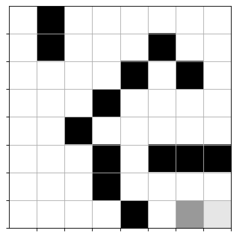

```python
completion_check(model, qmaze)
show(qmaze)
```

This cell will test your model for one game. It will start the pirate at the top-left corner and run **play_game()**. The agent should find a path from the starting position to the target (treasure). The treasure is located in the bottom-right corner.

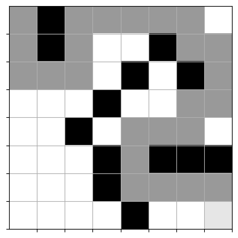

```python
pirate_start = (0, 0)
play_game(model, qmaze, pirate_start)
show(qmaze)
```

## Save and Submit Your Work

**Hint:** To use the markdown block below, double click in the **Type Markdown and LaTeX: 𝛼2** block below, to turn it back to html, Run the cell.

After you have finished creating the code for your notebook, save your work. Make sure that your notebook contains your name in the filename (e.g. Doe_Jane_ProjectTwo.html). Download this file as an .html file clicking on **file** in *Jupyter Notebook*, navigating down to **Download as** and clicking on **.html**. Download a copy of your .html file and submit it to Brightspace.